### Homework2, Stat 627

### Zhuangye Chen

```r
# Load the packages and read in the data
suppressPackageStartupMessages(library(plyr))
suppressPackageStartupMessages(library(dplyr))
suppressPackageStartupMessages(library(ggplot2))
suppressPackageStartupMessages(library(tidyr))
gapminder <- read.delim("http://www.stat.ubc.ca/~jenny/notOcto/STAT545A/examples/gapminder/data/gapminderDataFiveYear.txt")
str(gapminder)
```

```
## 'data.frame':    1704 obs. of  6 variables:
##  $ country  : Factor w/ 142 levels "Afghanistan",..: 1 1 1 1 1 1 1 1 1 1 ...
##  $ year     : int  1952 1957 1962 1967 1972 1977 1982 1987 1992 1997 ...
##  $ pop      : num  8425333 9240934 10267083 11537966 13079460 ...
##  $ continent: Factor w/ 5 levels "Africa","Americas",..: 3 3 3 3 3 3 3 3 3 3 ...
##  $ lifeExp  : num  28.8 30.3 32 34 36.1 ...
##  $ gdpPercap: num  779 821 853 836 740 ...
```

Note that there are 142 rows for a year and there are 12 years in total.

### Part 1

#### Task1: Get the maximum and minimum of GDP per capita for all continents.

```r
gapminder %>% group_by(continent) %>% summarise(min(gdpPercap), max(gdpPercap))
```

```
## Source: local data frame [5 x 3]
##
##   continent min(gdpPercap) max(gdpPercap)
##      (fctr)          (dbl)          (dbl)
## 1    Africa       241.1659       21951.21
## 2  Americas      1201.6372       42951.65
## 3      Asia       331.0000      113523.13
## 4    Europe       973.5332       49357.19
## 5   Oceania     10039.5956       34435.37
```

#### Task2: Look at the spread of GDP per capita within the continents.

```r
gapminder %>% group_by(continent) %>% summarise(var(gdpPercap))
```

```
## Source: local data frame [5 x 2]
##
##   continent var(gdpPercap)
##      (fctr)          (dbl)
## 1    Africa        7997187
## 2  Americas       40918591
## 3      Asia      197272506
## 4    Europe       87520020
## 5   Oceania       40436669
```

#### Task3: Compute a weighted mean for different years, weighting by population.

```r
# A data.frame to store the year and the weighted mean
weightedLifeExpMean <- data.frame("year" = unique(gapminder$year),
                                  "WeightedLifeExpMean" = numeric(12))
j = 1
for (i in unique(gapminder$year)) {
  dataOfYear <- select(filter(gapminder, year == i), pop, lifeExp)
  weightedLifeExpMean$WeightedLifeExpMean[j] <- (dataOfYear %>% summarize(sum(pop*lifeExp) / sum(pop)))[[1]]
  j = j+1
}
weightedLifeExpMean
```

```
##    year WeightedLifeExpMean
## 1  1952            48.94424
## 2  1957            52.12189
## 3  1962            52.32438
## 4  1967            56.98431
## 5  1972            59.51478
## 6  1977            61.23726
## 7  1982            62.88176
## 8  1987            64.41635
## 9  1992            65.64590
## 10 1997            66.84934
## 11 2002            67.83904
## 12 2007            68.91909
```

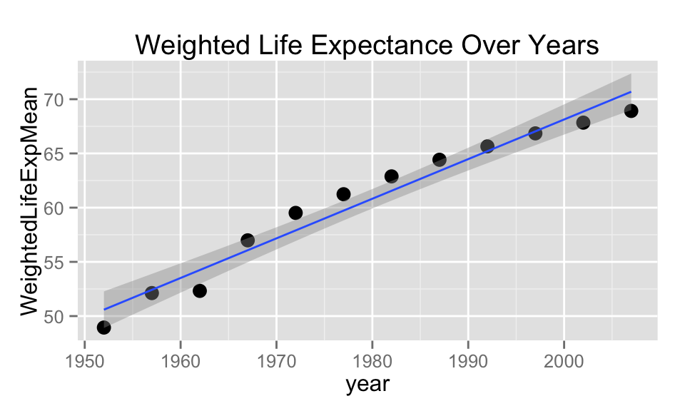

```r
# A plot to show the points and a regression funciton to show the trend
g <- ggplot(weightedLifeExpMean, aes(x = year, y = WeightedLifeExpMean))
g + geom_point(size = 3.5) + geom_smooth(method = lm) + ggtitle("Weighted Life Expectance Over Years")
```

From the plot we can see that there is an obvious increasing trend in weighted life expectance (weighted by population) over years.

#### Task4: How is life expectancy changing over time on different continents?

Calculate the meadian of life expectancy for each continent over years. The reason I choose median here is that mean is largely influenced by outliers and by the plots below we can see that there are quite a few outliers there.

```r
LEmedian <- gapminder %>% group_by(continent, year) %>% summarise(median(lifeExp))
# Use "spread" function from tidyr package to reshape the data to a wide form
LEwide <- spread(LEmedian, key = year, value = "median(lifeExp)")
# The data if too wide (13 columns in total) to display fully, just display the first 4 and last 4 years
LEwide[, c(1:5, (dim(LEwide)[2]-3):dim(LEwide)[2])]
```

```
## Source: local data frame [5 x 9]
##
##   continent   1952    1957    1962    1967   1992   1997    2002    2007
##      (fctr)  (dbl)   (dbl)   (dbl)   (dbl)  (dbl)  (dbl)   (dbl)   (dbl)
## 1    Africa 38.833 40.5925 42.6305 44.6985 52.429 52.759 51.2355 52.9265
## 2  Americas 54.745 56.0740 58.2990 60.5230 69.862 72.146 72.0470 72.8990
## 3      Asia 44.869 48.2840 49.3250 53.6550 68.690 70.265 71.0280 72.3960
## 4    Europe 65.900 67.6500 69.5250 70.6100 75.451 76.116 77.5365 78.6085
## 5   Oceania 69.255 70.2950 71.0850 71.3100 76.945 78.190 79.7400 80.7195
```

It is better to answer this question with the plot.

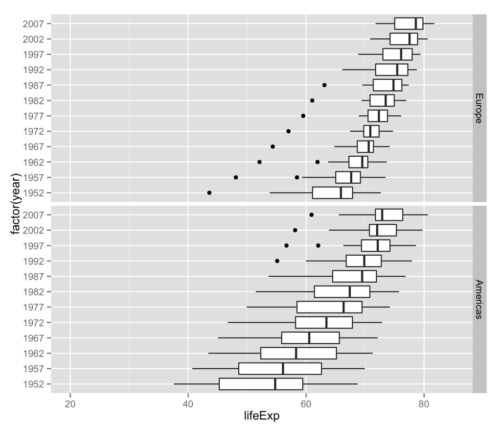

```r
# Refactorize 'continent' variable for a better order in facettting
gapminder$continent <- factor(gapminder$continent, levels = c("Europe", "Americas", "Asia", "Africa", "Oceania"))
t1 <- filter(gapminder, continent %in% c('Europe', 'Americas')) %>% ggplot(aes(x = factor(year), y = lifeExp))
t1 + geom_boxplot() + coord_flip() + facet_grid(continent~.) + ylim(20, 85)
```

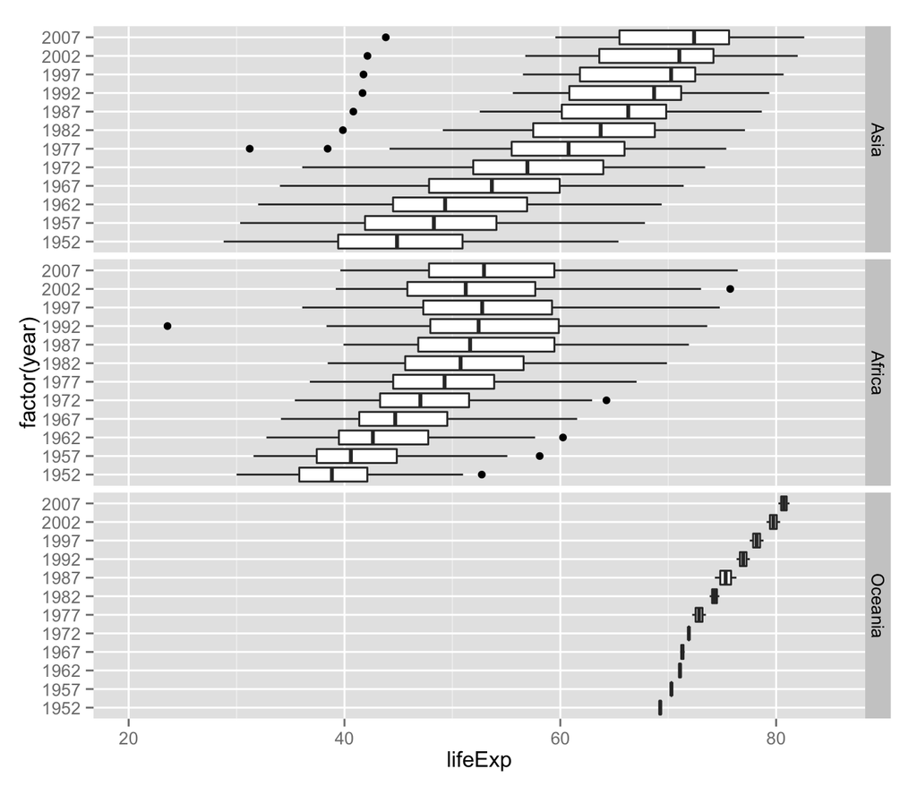

```r
t2 <- filter(gapminder, continent %in% c('Asia', 'Africa', 'Oceania')) %>% ggplot(aes(x = factor(year), y = lifeExp))
t2 + geom_boxplot() + coord_flip() + facet_grid(continent~.) + ylim(20, 85)
```

First of all, all 5 continents witnessed an increase in life expectancy over years. The median of life expectancy of Africa increased from 38.833 to 52.9265, Americas from 54.745 to 72.899 and so on.

### Part 2

#### Task: Write a function to compute something interesting on a piece of the Gapminder data.

Make it something you can’t easily do with built-in functions. Make it something that’s not trivial to do with the simple dplyr verbs. Funtion: Fit a linear regression of life expectancy on year, find the largest standard residual of the fit. Return the year if its residual is greater than 2, return NULL if not.

```r
bigRes <- function(data, offset = 1952) {
  lmfit <- lm(lifeExp ~ I(year - offset), data)
  absRes <- abs(rstandard(lmfit))
  if (max(absRes) > 2) {
    return(data$year[which.max(absRes)])
  } else {
    return(NULL)
  }
}
countryOutlierYear <- ddply(gapminder, ~ country, bigRes)
str(countryOutlierYear)
```

```
## 'data.frame':    70 obs. of  2 variables:
##  $ country: Factor w/ 142 levels "Afghanistan",..: 2 3 5 8 10 13 15 16 19 23 ...
##  $ V1     : int  1952 2007 1957 2007 1972 1952 1952 1952 1977 2007 ...
```

```r
head(countryOutlierYear)
```

```
##                  country   V1
## 1                Albania 1952
## 2                Algeria 2007
## 3              Argentina 1957
## 4                Bahrain 2007
## 5                Belgium 1972
## 6 Bosnia and Herzegovina 1952
```

```r
tail(countryOutlierYear)
```

```
##                country   V1
## 65               Syria 2007
## 66              Taiwan 1952
## 67 Trinidad and Tobago 1952
## 68             Tunisia 2007
## 69              Turkey 1952
## 70  West Bank and Gaza 2007
```

So there are 70 countries whose largest residual is greater 2, and we get the year, which is worth further investigating, for these countries.